# Alberto charts

www.databrew.cc

2020-03-28

```r
## Load libraries
library(covid19)
library(ggplot2)
library(lubridate)
library(dplyr)
library(ggplot2)
ylog <- TRUE
options(scipen = '999')
library(tidyr)
```

# FINAL CHARTS FOR PUBLICATION

1. All notified cases in Italy and Spain (cumulative and per day). So the line that shows cases per day is well seen, it would be great if we could make use of both axis (with different scales).
2. All notified deaths in Italy and Spain (cumulative and per day). Both axis
3. All notificed ICU deaths in Italy and Spain (cumulative and per day). Both axis
4. Case notification risk (per 100.000) in Italy and Spain (cumulative and per day)
5. COVID-19 mortality risk (per 100,000) in Italy and Spain (cumulative and per day)
6. COVID-19 ICU admission risk (per 100.000) in Italy and Spain (cumulative and per day).

### A. All notified cases in Italy and Spain (cumulative and per day). So the line that shows cases per day is well seen, it would be great if we could make use of both axis (with different scales).

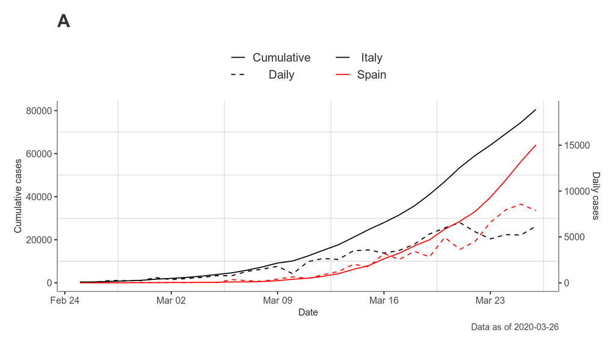

```r
cols <- c('black', 'red')
text_size <- 12
pd <- df %>% filter(country %in% c('Spain','Italy'))
max_date <- pd %>% group_by(country) %>% summarise(d = max(date)) %>% summarise(d = min(d)) %>% .$d
pd <- pd %>% left_join(world_pop)
pd$value <- pd$cases
pd$value_non_cum <- pd$cases_non_cum
pd <- pd %>% filter(value > 0,
                    date <= max_date)
pd <- pd %>% group_by(country, date) %>%
  summarise(value = sum(value, na.rm = TRUE),
            value_non_cum = sum(value_non_cum, na.rm = TRUE))

# Define transofrmer value
transformer <- ((max(pd$value) /  max(pd$value_non_cum)) )/ 40
# gather
pd <- pd %>%
  mutate(value_non_cum = value_non_cum / transformer) %>%
  gather(key, value, value:value_non_cum) %>%
  mutate(key = ifelse(key != 'value', 'Daily', 'Cumulative'))

aa <- ggplot(data = pd,
       aes(x = date,
           y = value,
           color = country,
           lty = key)) +
  theme_simple() +
  geom_line() +
  labs(x = 'Date',
       y = 'Cumulative cases',
       title = 'A',
       caption = paste0('Data as of ', max(pd$date))) +
  theme(axis.title = element_text(size = text_size),
        axis.text = element_text(size = text_size* 0.8)) +
  geom_text(data = pd %>% filter(date == max(date),
                                 key == 'Cumulative cases'),
            aes(x = date,
                y = value * 1.05,
                label = scales::comma(round(value, digits = 1))),
            alpha = 0.7,
            show.legend = FALSE) +
  scale_color_manual(name = '', values = cols) +
  scale_y_continuous(sec.axis = sec_axis(trans = ~ . * transformer,
                                         name = 'Daily cases')) +
  scale_linetype_manual(name = '', values = c(1,2)) +
  theme(legend.position = 'top',
        legend.title = element_blank(),
        axis.title = element_text(size = text_size * 0.8),
        legend.text = element_text(size = text_size * 0.98,
                                   hjust = 0.5)) +
  guides(lty = guide_legend(ncol = 1,
                            title.position = 'top'),
         color = guide_legend(ncol = 1,
                              title.position = 'top')) +
  xlim(as.Date('2020-02-25'),
       max(pd$date))
aa
```

### A.ii. All notified cases in Italy and Spain (cumulative and per day). RELATIVE TIME

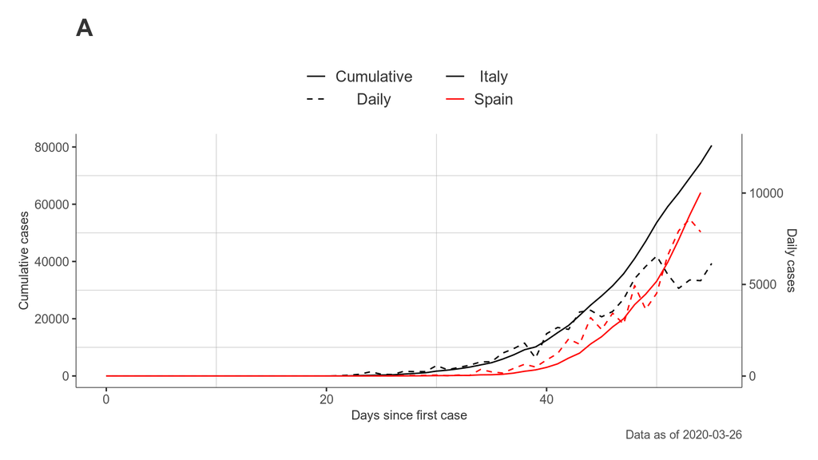

```r
make_day_zero <- function(x, start_value = 1){
  x %>%
    arrange(date) %>%
    group_by(country) %>%
    mutate(day0 = min(date[value >= start_value])) %>%
    mutate(date = as.numeric(date - day0))
}
make_day_zero_var <- function(x, start_value = 1, start_var = 'cases'){
  x$start_var <- as.numeric(unlist(x[,start_var]))
  x <- x %>%
    arrange(date) %>%
    group_by(country) %>%
    mutate(day0 = min(date[start_var >= start_value])) %>%
    mutate(date = as.numeric(date - day0))
}

cols <- c('black', 'red')
text_size <- 12
pd <- df %>% filter(country %in% c('Spain','Italy'))
max_date <- pd %>% group_by(country) %>% summarise(d = max(date)) %>% summarise(d = min(d)) %>% .$d
pd <- pd %>% left_join(world_pop)
pd$value <- pd$cases
pd$value_non_cum <- pd$cases_non_cum
pd <- pd %>% filter(value > 0,
                    date <= max_date)
pd <- pd %>%
  make_day_zero_var(start_value = 1, start_var = 'cases') %>%
  group_by(country, date) %>%
  summarise(value = sum(value, na.rm = TRUE),
            value_non_cum = sum(value_non_cum, na.rm = TRUE))

# Define transofrmer value
transformer <- ((max(pd$value) /  max(pd$value_non_cum)) )/ 60
# gather
pd <- pd %>%
  mutate(value_non_cum = value_non_cum / transformer) %>%
  gather(key, value, value:value_non_cum) %>%
  mutate(key = ifelse(key != 'value', 'Daily', 'Cumulative'))

aaii <- ggplot(data = pd,
       aes(x = date,
           y = value,
           color = country,
           lty = key)) +
  theme_simple() +
  geom_line() +
  labs(x = 'Days since first case',
       y = 'Cumulative cases',
       title = 'A',
       caption = paste0('Data as of ',max_date)) +
  theme(axis.title = element_text(size = text_size),
        axis.text = element_text(size = text_size* 0.8)) +
  geom_text(data = pd %>% filter(date == max(date),
                                 key == 'Cumulative cases'),
            aes(x = date,
                y = value * 1.05,
                label = scales::comma(round(value, digits = 1))),
            alpha = 0.7,
            show.legend = FALSE) +
  scale_color_manual(name = '', values = cols) +
  scale_y_continuous(sec.axis = sec_axis(trans = ~ . * transformer,
                                         name = 'Daily cases')) +
  scale_linetype_manual(name = '', values = c(1,2)) +
  theme(legend.position = 'top',
        legend.title = element_blank(),
        axis.title = element_text(size = text_size * 0.8),
        legend.text = element_text(size = text_size * 0.98,
                                   hjust = 0.5)) +
  guides(lty = guide_legend(ncol = 1,
                            title.position = 'top'),
         color = guide_legend(ncol = 1,
                              title.position = 'top'))
aaii
```

## B All notified deaths in Italy and Spain (cumulative and per day). Both axis

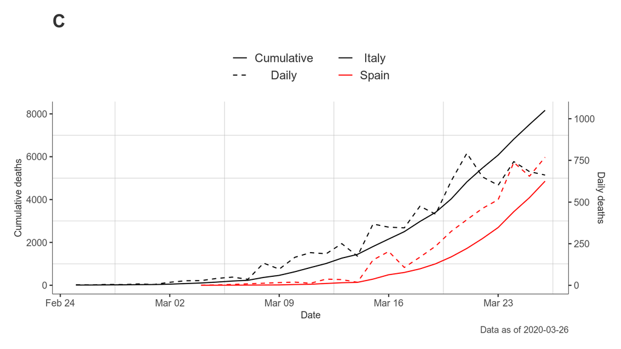

```r
cols <- c('black', 'red')
pd <- df %>% filter(country %in% c('Spain','Italy'))
max_date <- pd %>% group_by(country) %>% summarise(d = max(date)) %>% summarise(d = min(d)) %>% .$d
pd <- pd %>% left_join(world_pop)
pd$value <- pd$deaths
pd$value_non_cum <- pd$deaths_non_cum
pd <- pd %>% filter(value > 0,
                    date <= max_date)
pd <- pd %>%
  # make_day_zero() %>%
  group_by(country, date) %>%
  summarise(value = sum(value, na.rm = TRUE),
            value_non_cum = sum(value_non_cum, na.rm = TRUE))

# Define transofrmer value
transformer <- ((max(pd$value) /  max(pd$value_non_cum)) )/ 80
# gather
pd <- pd %>%
  mutate(value_non_cum = value_non_cum / transformer) %>%
  gather(key, value, value:value_non_cum) %>%
  mutate(key = ifelse(key != 'value', 'Daily', 'Cumulative'))

bb <- ggplot(data = pd,
       aes(x = date,
           y = value,
           color = country,
           lty = key)) +
  theme_simple() +
  geom_line() +
  labs(x = 'Date',
       y = 'Cumulative deaths',
       title = 'C',
       caption = paste0('Data as of ', max(pd$date))) +
  theme(axis.title = element_text(size = text_size),
        axis.text = element_text(size = text_size* 0.8)) +
  geom_text(data = pd %>% filter(date == max(date),
                                 key == 'Cumulative deaths'),
            aes(x = date,
                y = value * 1.05,
                label = scales::comma(round(value, digits = 1))),
            alpha = 0.7,
            show.legend = FALSE) +
  scale_color_manual(name = '', values = cols) +
  scale_y_continuous(sec.axis = sec_axis(trans = ~ . * transformer,
                                         name = 'Daily deaths')) +
  scale_linetype_manual(name = '', values = c(1,2)) +
  theme(legend.position = 'top',
        legend.title = element_blank(),
        axis.title = element_text(size = text_size * 0.8),
        legend.text = element_text(size = text_size * 0.98,
                                   hjust = 0.5)) +
  guides(lty = guide_legend(ncol = 1,
                            title.position = 'top'),
         color = guide_legend(ncol = 1,
                              title.position = 'top')) +
  xlim(as.Date('2020-02-25'),
       max(pd$date))
bb
```

## B.ii. All notified deaths in Italy and Spain (cumulative and per day). Both axis

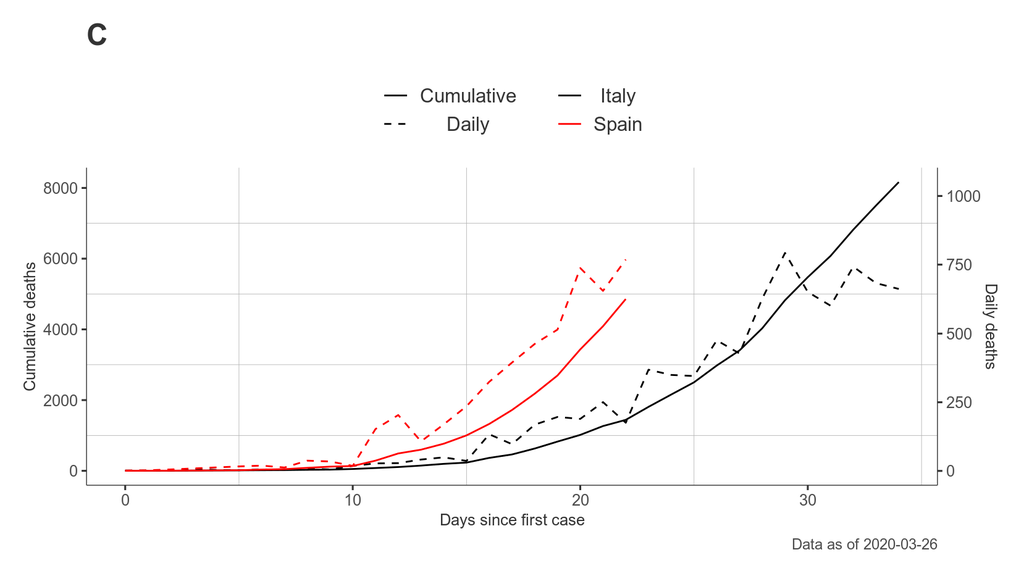

```r
cols <- c('black', 'red')
pd <- df %>% filter(country %in% c('Spain','Italy'))
max_date <- pd %>% group_by(country) %>% summarise(d = max(date)) %>% summarise(d = min(d)) %>% .$d
pd <- pd %>% left_join(world_pop)
pd$value <- pd$deaths
pd$value_non_cum <- pd$deaths_non_cum
pd <- pd %>% filter(value > 0,
                    date <= max_date)
pd <- pd %>%
  make_day_zero_var(start_value = 1, start_var = 'cases') %>%
  group_by(country, date) %>%
  summarise(value = sum(value, na.rm = TRUE),
            value_non_cum = sum(value_non_cum, na.rm = TRUE))

# Define transofrmer value
transformer <- ((max(pd$value) /  max(pd$value_non_cum)) )/ 80
# gather
pd <- pd %>%
  mutate(value_non_cum = value_non_cum / transformer) %>%
  gather(key, value, value:value_non_cum) %>%
  mutate(key = ifelse(key != 'value', 'Daily', 'Cumulative'))

bbii <- ggplot(data = pd,
       aes(x = date,
           y = value,
           color = country,
           lty = key)) +
  theme_simple() +
  geom_line() +
  labs(x = 'Days since first case',
       y = 'Cumulative deaths',
       title = 'C',
       caption = paste0('Data as of ', max_date)) +
  theme(axis.title = element_text(size = text_size),
        axis.text = element_text(size = text_size* 0.8)) +
  geom_text(data = pd %>% filter(date == max(date),
                                 key == 'Cumulative deaths'),
            aes(x = date,
                y = value * 1.05,
                label = scales::comma(round(value, digits = 1))),
            alpha = 0.7,
            show.legend = FALSE) +
  scale_color_manual(name = '', values = cols) +
  scale_y_continuous(sec.axis = sec_axis(trans = ~ . * transformer,
                                         name = 'Daily deaths')) +
  scale_linetype_manual(name = '', values = c(1,2)) +
  theme(legend.position = 'top',
        legend.title = element_blank(),
        axis.title = element_text(size = text_size * 0.8),
        legend.text = element_text(size = text_size * 0.98,
                                   hjust = 0.5)) +
  guides(lty = guide_legend(ncol = 1,
                            title.position = 'top'),
         color = guide_legend(ncol = 1,
                              title.position = 'top'))
bbii
```

## C. ICU in Italy and Spain cumulative and per day

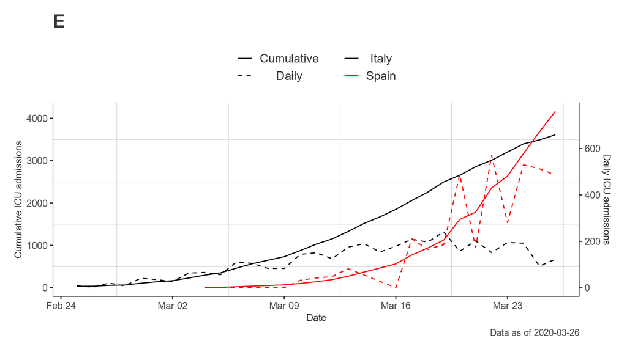

```r
cols <- c('black', 'red')
pd <- df %>% filter(country %in% c('Spain','Italy'))
max_date <- pd %>% group_by(country) %>% summarise(d = max(date)) %>% summarise(d = min(d)) %>% .$d
pd <- pd %>% left_join(world_pop)
pd$value <- pd$uci
pd$value_non_cum <- pd$uci_non_cum
pd <- pd %>% filter(value > 0,
                    date <= max_date)
pd <- pd %>% group_by(country, date) %>%
  summarise(value = sum(value, na.rm = TRUE),
            value_non_cum = sum(value_non_cum, na.rm = TRUE))

# Define transofrmer value
transformer <- ((max(pd$value) /  max(pd$value_non_cum)) )/ 40
# gather
pd <- pd %>%
  mutate(value_non_cum = value_non_cum / transformer) %>%
  gather(key, value, value:value_non_cum) %>%
  mutate(key = ifelse(key != 'value', 'Daily', 'Cumulative'))

cc <- ggplot(data = pd,
       aes(x = date,
           y = value,
           color = country,
           lty = key)) +
  theme_simple() +
  geom_line() +
  labs(x = 'Date',
       y = 'Cumulative ICU admissions',
       title = 'E',
       caption = paste0('Data as of ', max(pd$date))) +
  theme(axis.title = element_text(size = text_size),
        axis.text = element_text(size = text_size* 0.8)) +
  geom_text(data = pd %>% filter(date == max(date),
                                 key == 'Cumulative ICU admissions'),
            aes(x = date,
                y = value * 1.05,
                label = scales::comma(round(value, digits = 1))),
            alpha = 0.7,
            show.legend = FALSE) +
  scale_color_manual(name = '', values = cols) +
  scale_y_continuous(sec.axis = sec_axis(trans = ~ . * transformer,
                                         name = 'Daily ICU admissions')) +
  scale_linetype_manual(name = '', values = c(1,2)) +
  theme(legend.position = 'top',
        legend.title = element_blank(),
        axis.title = element_text(size = text_size * 0.8),
        legend.text = element_text(size = text_size * 0.98,
                                   hjust = 0.5)) +
  guides(lty = guide_legend(ncol = 1,
                            title.position = 'top'),
         color = guide_legend(ncol = 1,
                              title.position = 'top')) +
  xlim(as.Date('2020-02-25'),
       max(pd$date))
cc
```

## C.ii. ICU in Italy and Spain cumulative and per day

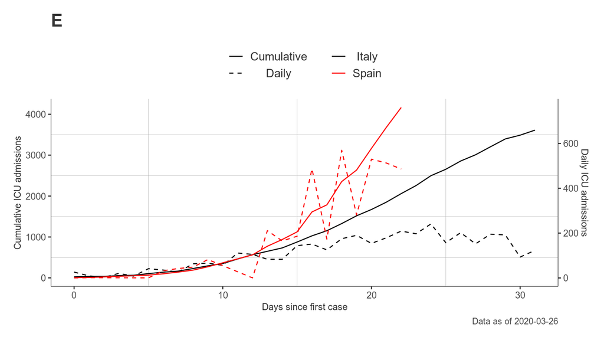

```r
cols <- c('black', 'red')
pd <- df %>% filter(country %in% c('Spain','Italy'))
max_date <- pd %>% group_by(country) %>% summarise(d = max(date)) %>% summarise(d = min(d)) %>% .$d
pd <- pd %>% left_join(world_pop)
pd$value <- pd$uci
pd$value_non_cum <- pd$uci_non_cum
pd <- pd %>% filter(value > 0,
                    date <= max_date)
pd <- pd %>%
  make_day_zero_var(start_value = 1, start_var = 'cases') %>%
  group_by(country, date) %>%
  summarise(value = sum(value, na.rm = TRUE),
            value_non_cum = sum(value_non_cum, na.rm = TRUE))

# Define transofrmer value
transformer <- ((max(pd$value) /  max(pd$value_non_cum)) )/ 40
# gather
pd <- pd %>%
  mutate(value_non_cum = value_non_cum / transformer) %>%
  gather(key, value, value:value_non_cum) %>%
  mutate(key = ifelse(key != 'value', 'Daily', 'Cumulative'))

ccii <- ggplot(data = pd,
       aes(x = date,
           y = value,
           color = country,
           lty = key)) +
  theme_simple() +
  geom_line() +
  labs(x = 'Days since first case',
       y = 'Cumulative ICU admissions',
       title = 'E',
       caption = paste0('Data as of ', max_date)) +
  theme(axis.title = element_text(size = text_size),
        axis.text = element_text(size = text_size* 0.8)) +
  geom_text(data = pd %>% filter(date == max(date),
                                 key == 'Cumulative ICU admissions'),
            aes(x = date,
                y = value * 1.05,
                label = scales::comma(round(value, digits = 1))),
            alpha = 0.7,
            show.legend = FALSE) +
  scale_color_manual(name = '', values = cols) +
  scale_y_continuous(sec.axis = sec_axis(trans = ~ . * transformer,
                                         name = 'Daily ICU admissions')) +
  scale_linetype_manual(name = '', values = c(1,2)) +
  theme(legend.position = 'top',
        legend.title = element_blank(),
        axis.title = element_text(size = text_size * 0.8),
        legend.text = element_text(size = text_size * 0.98,
                                   hjust = 0.5)) +
  guides(lty = guide_legend(ncol = 1,
                            title.position = 'top'),
         color = guide_legend(ncol = 1,
                              title.position = 'top'))
ccii
```

## D. Case notification risk (per 100.000) in Italy and Spain (cumulative and per day)

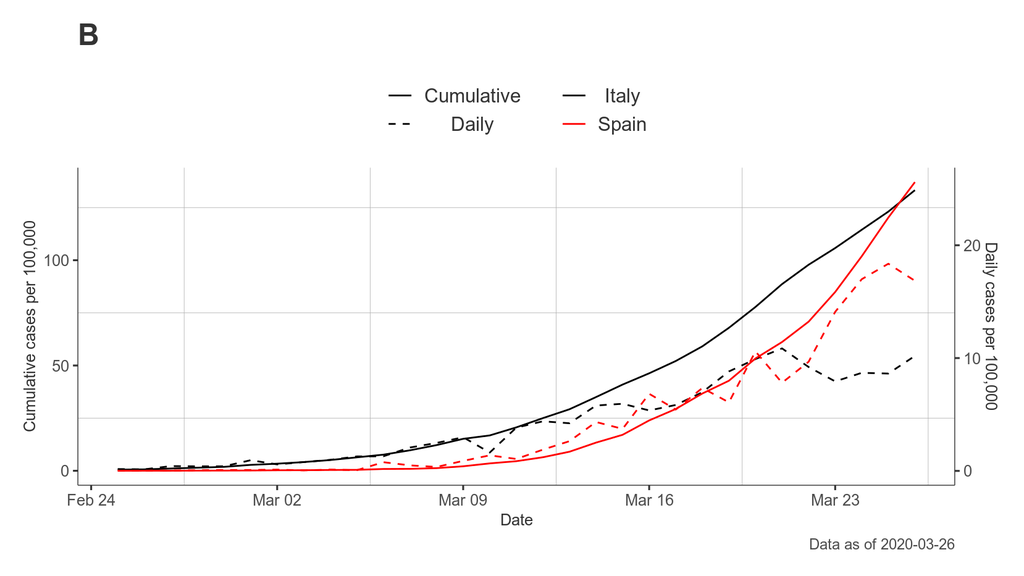

```r
cols <- c('black', 'red')
pd <- df %>% filter(country %in% c('Spain','Italy'))
max_date <- pd %>% group_by(country) %>% summarise(d = max(date)) %>% summarise(d = min(d)) %>% .$d
pd <- pd %>% left_join(world_pop)
pd$value <- pd$cases / pd$pop * 100000
pd$value_non_cum <- pd$cases_non_cum / pd$pop * 100000
pd <- pd %>% filter(value > 0,
                    date <= max_date)
pd <- pd %>% group_by(country, date) %>%
  summarise(value = sum(value, na.rm = TRUE),
            value_non_cum = sum(value_non_cum, na.rm = TRUE))

# Define transofrmer value
transformer <- ((max(pd$value) /  max(pd$value_non_cum)) )/ 40
# gather
pd <- pd %>%
  mutate(value_non_cum = value_non_cum / transformer) %>%
  gather(key, value, value:value_non_cum) %>%
  mutate(key = ifelse(key != 'value', 'Daily', 'Cumulative'))

dd <- ggplot(data = pd,
       aes(x = date,
           y = value,
           color = country,
           lty = key)) +
  theme_simple() +
  geom_line() +
  labs(x = 'Date',
       y = 'Cumulative cases per 100,000',
       title = 'B',
       caption = paste0('Data as of ', max(pd$date))) +
  theme(axis.title = element_text(size = text_size),
        axis.text = element_text(size = text_size* 0.8)) +
  geom_text(data = pd %>% filter(date == max(date),
                                 key == 'Cumulative cases per 100,000'),
            aes(x = date,
                y = value * 1.05,
                label = scales::comma(round(value, digits = 1))),
            alpha = 0.7,
            show.legend = FALSE) +
  scale_color_manual(name = '', values = cols) +
  scale_y_continuous(sec.axis = sec_axis(trans = ~ . * transformer,
                                         name = 'Daily cases per 100,000')) +
  scale_linetype_manual(name = '', values = c(1,2)) +
  theme(legend.position = 'top',
        legend.title = element_blank(),
        axis.title = element_text(size = text_size * 0.8),
        legend.text = element_text(size = text_size * 0.98,
                                   hjust = 0.5)) +
  guides(lty = guide_legend(ncol = 1,
                            title.position = 'top'),
         color = guide_legend(ncol = 1,
                              title.position = 'top')) +
  xlim(as.Date('2020-02-25'),
       max(pd$date))
dd
```

## D.ii. Case notification risk (per 100.000) in Italy and Spain (cumulative and per day)

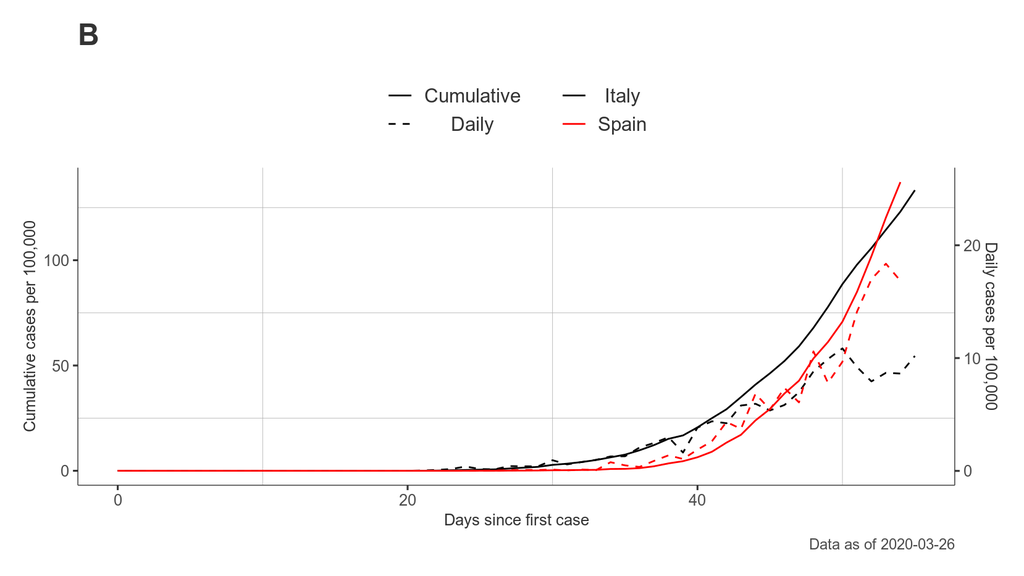

```r
make_day_zero_var <- function(x, start_value = 1, start_var = 'cases'){
  x$start_var <- as.numeric(unlist(x[,start_var]))
  x <- x %>%
    arrange(date) %>%
    group_by(country) %>%
    mutate(day0 = min(date[start_var >= start_value])) %>%
    mutate(date = as.numeric(date - day0))
}


cols <- c('black', 'red')
pd <- df %>% filter(country %in% c('Spain','Italy'))
max_date <- pd %>% group_by(country) %>% summarise(d = max(date)) %>% summarise(d = min(d)) %>% .$d
pd <- pd %>% left_join(world_pop)
pd$value <- pd$cases / pd$pop * 100000
pd$value_non_cum <- pd$cases_non_cum / pd$pop * 100000
pd <- pd %>% filter(value > 0,
                    date <= max_date)
pd <- pd %>%
  make_day_zero_var(start_value = 1, start_var = 'cases') %>%
  group_by(country, date) %>%
  summarise(value = sum(value, na.rm = TRUE),
            value_non_cum = sum(value_non_cum, na.rm = TRUE))

# Define transofrmer value
transformer <- ((max(pd$value) /  max(pd$value_non_cum)) )/ 40
# gather
pd <- pd %>%
  mutate(value_non_cum = value_non_cum / transformer) %>%
  gather(key, value, value:value_non_cum) %>%
  mutate(key = ifelse(key != 'value', 'Daily', 'Cumulative')) %>%
  filter(date >= -5)

ddii <- ggplot(data = pd,
       aes(x = date,
           y = value,
           color = country,
           lty = key)) +
  theme_simple() +
  geom_line() +
  labs(x = 'Days since first case',
       y = 'Cumulative cases per 100,000',
       title = 'B',
       caption = paste0('Data as of ',max_date)) +
  theme(axis.title = element_text(size = text_size),
        axis.text = element_text(size = text_size* 0.8)) +
  geom_text(data = pd %>% filter(date == max(date),
                                 key == 'Cumulative cases per 100,000'),
            aes(x = date,
                y = value * 1.05,
                label = scales::comma(round(value, digits = 1))),
            alpha = 0.7,
            show.legend = FALSE) +
  scale_color_manual(name = '', values = cols) +
  scale_y_continuous(sec.axis = sec_axis(trans = ~ . * transformer,
                                         name = 'Daily cases per 100,000')) +
  scale_linetype_manual(name = '', values = c(1,2)) +
  theme(legend.position = 'top',
        legend.title = element_blank(),
        axis.title = element_text(size = text_size * 0.8),
        legend.text = element_text(size = text_size * 0.98,
                                   hjust = 0.5)) +
  guides(lty = guide_legend(ncol = 1,
                            title.position = 'top'),
         color = guide_legend(ncol = 1,
                              title.position = 'top'))
ddii
```

## E Mortality risk

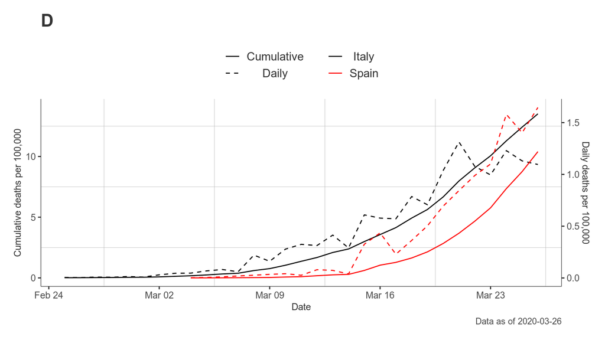

```r
cols <- c('black', 'red')
pd <- df %>% filter(country %in% c('Spain','Italy'))
max_date <- pd %>% group_by(country) %>% summarise(d = max(date)) %>% summarise(d = min(d)) %>% .$d
pd <- pd %>% left_join(world_pop)
pd$value <- pd$deaths / pd$pop * 100000
pd$value_non_cum <- pd$deaths_non_cum / pd$pop * 100000
pd <- pd %>% filter(value > 0,
                    date <= max_date)
pd <- pd %>%
  group_by(country, date) %>%
  summarise(value = sum(value, na.rm = TRUE),
            value_non_cum = sum(value_non_cum, na.rm = TRUE))

# Define transofrmer value
transformer <- ((max(pd$value) /  max(pd$value_non_cum)) )/ 70
# gather
pd <- pd %>%
  mutate(value_non_cum = value_non_cum / transformer) %>%
  gather(key, value, value:value_non_cum) %>%
  mutate(key = ifelse(key != 'value', 'Daily', 'Cumulative'))

ee <- ggplot(data = pd,
       aes(x = date,
           y = value,
           color = country,
           lty = key)) +
  theme_simple() +
  geom_line() +
  labs(x = 'Date',
       y = 'Cumulative deaths per 100,000',
       title = 'D',
       caption = paste0('Data as of ', max(pd$date))) +
  theme(axis.title = element_text(size = text_size),
        axis.text = element_text(size = text_size* 0.8)) +
  geom_text(data = pd %>% filter(date == max(date),
                                 key == 'Cumulative deaths per 100,000'),
            aes(x = date,
                y = value * 1.05,
                label = scales::comma(round(value, digits = 1))),
            alpha = 0.7,
            show.legend = FALSE) +
  scale_color_manual(name = '', values = cols) +
  scale_y_continuous(sec.axis = sec_axis(trans = ~ . * transformer,
                                         name = 'Daily deaths per 100,000')) +
  scale_linetype_manual(name = '', values = c(1,2)) +
  theme(legend.position = 'top',
        legend.title = element_blank(),
        axis.title = element_text(size = text_size * 0.8),
        legend.text = element_text(size = text_size * 0.98,
                                   hjust = 0.5)) +
  guides(lty = guide_legend(ncol = 1,
                            title.position = 'top'),
         color = guide_legend(ncol = 1,
                              title.position = 'top')) +
  xlim(as.Date('2020-02-25'),
       max(pd$date))
ee
```

## E.ii Mortality risk

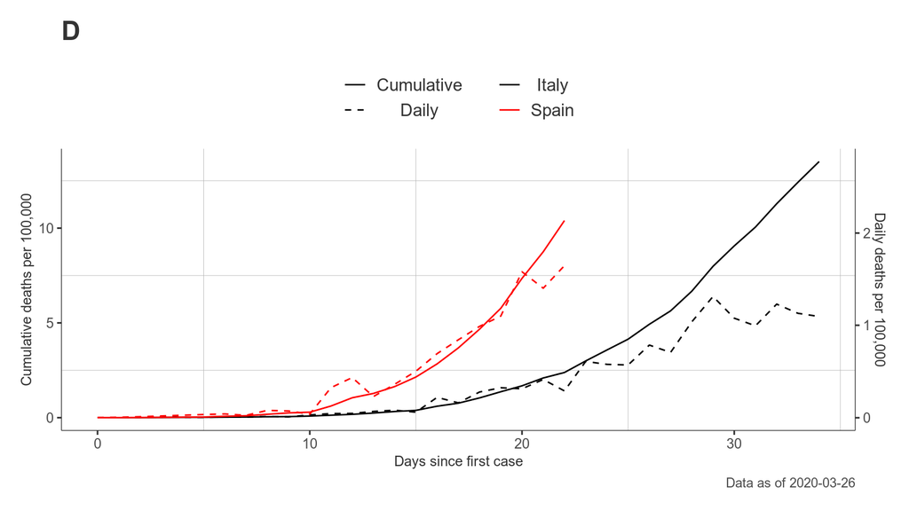

```r
cols <- c('black', 'red')
pd <- df %>% filter(country %in% c('Spain','Italy'))
max_date <- pd %>% group_by(country) %>% summarise(d = max(date)) %>% summarise(d = min(d)) %>% .$d
pd <- pd %>% left_join(world_pop)
pd$value <- pd$deaths / pd$pop * 100000
pd$value_non_cum <- pd$deaths_non_cum / pd$pop * 100000
pd <- pd %>% filter(value > 0,
                    date <= max_date)
pd <- pd %>%
  make_day_zero_var(start_value = 1, start_var = 'cases') %>%
  group_by(country, date) %>%
  summarise(value = sum(value, na.rm = TRUE),
            value_non_cum = sum(value_non_cum, na.rm = TRUE))

# Define transofrmer value
transformer <- ((max(pd$value) /  max(pd$value_non_cum)) )/ 40
# gather
pd <- pd %>%
  mutate(value_non_cum = value_non_cum / transformer) %>%
  gather(key, value, value:value_non_cum) %>%
  mutate(key = ifelse(key != 'value', 'Daily', 'Cumulative')) %>%
  filter(date >= -5)

eeii <- ggplot(data = pd,
       aes(x = date,
           y = value,
           color = country,
           lty = key)) +
  theme_simple() +
  geom_line() +
  labs(x = 'Days since first case',
       y = 'Cumulative deaths per 100,000',
       title = 'D',
       caption = paste0('Data as of ', max_date)) +
  theme(axis.title = element_text(size = text_size),
        axis.text = element_text(size = text_size* 0.8)) +
  geom_text(data = pd %>% filter(date == max(date),
                                 key == 'Cumulative deaths per 100,000'),
            aes(x = date,
                y = value * 1.05,
                label = scales::comma(round(value, digits = 1))),
            alpha = 0.7,
            show.legend = FALSE) +
  scale_color_manual(name = '', values = cols) +
  scale_y_continuous(sec.axis = sec_axis(trans = ~ . * transformer,
                                         name = 'Daily deaths per 100,000')) +
  scale_linetype_manual(name = '', values = c(1,2)) +
  theme(legend.position = 'top',
        legend.title = element_blank(),
        axis.title = element_text(size = text_size * 0.8),
        legend.text = element_text(size = text_size * 0.98,
                                   hjust = 0.5)) +
  guides(lty = guide_legend(ncol = 1,
                            title.position = 'top'),
         color = guide_legend(ncol = 1,
                              title.position = 'top'))
eeii
```

## F ICU admission risk

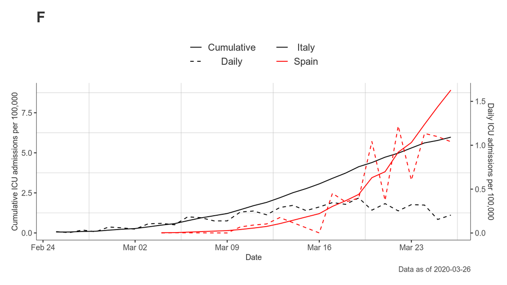

```r
cols <- c('black', 'red')
pd <- df %>% filter(country %in% c('Spain','Italy'))
max_date <- pd %>% group_by(country) %>% summarise(d = max(date)) %>% summarise(d = min(d)) %>% .$d
pd <- pd %>% left_join(world_pop)
pd$value <- pd$uci / pd$pop * 100000
pd$value_non_cum <- pd$uci_non_cum / pd$pop * 100000
pd <- pd %>% filter(value > 0,
                    date <= max_date)
pd <- pd %>% group_by(country, date) %>%
  summarise(value = sum(value, na.rm = TRUE),
            value_non_cum = sum(value_non_cum, na.rm = TRUE))

# Define transofrmer value
transformer <- ((max(pd$value) /  max(pd$value_non_cum)) )/ 40
# gather
pd <- pd %>%
  mutate(value_non_cum = value_non_cum / transformer) %>%
  gather(key, value, value:value_non_cum) %>%
  mutate(key = ifelse(key != 'value', 'Daily', 'Cumulative'))

ff <- ggplot(data = pd,
       aes(x = date,
           y = value,
           color = country,
           lty = key)) +
  theme_simple() +
  geom_line() +
  labs(x = 'Date',
       y = 'Cumulative ICU admissions per 100,000',
       title = 'F',
       caption = paste0('Data as of ', max(pd$date))) +
  theme(axis.title = element_text(size = text_size),
        axis.text = element_text(size = text_size* 0.8)) +
  geom_text(data = pd %>% filter(date == max(date),
                                 key == 'Cumulative ICU admissions per 100,000'),
            aes(x = date,
                y = value * 1.05,
                label = scales::comma(round(value, digits = 1))),
            alpha = 0.7,
            show.legend = FALSE) +
  scale_color_manual(name = '', values = cols) +
  scale_y_continuous(sec.axis = sec_axis(trans = ~ . * transformer,
                                         name = 'Daily ICU admissions per 100,000')) +
  scale_linetype_manual(name = '', values = c(1,2)) +
  theme(legend.position = 'top',
        legend.title = element_blank(),
        axis.title = element_text(size = text_size * 0.8),
        legend.text = element_text(size = text_size * 0.98,
                                   hjust = 0.5)) +
  guides(lty = guide_legend(ncol = 1,
                            title.position = 'top'),
         color = guide_legend(ncol = 1,
                              title.position = 'top')) +
  xlim(as.Date('2020-02-25'),
       max(pd$date))
ff
```

## F.ii ICU admission risk

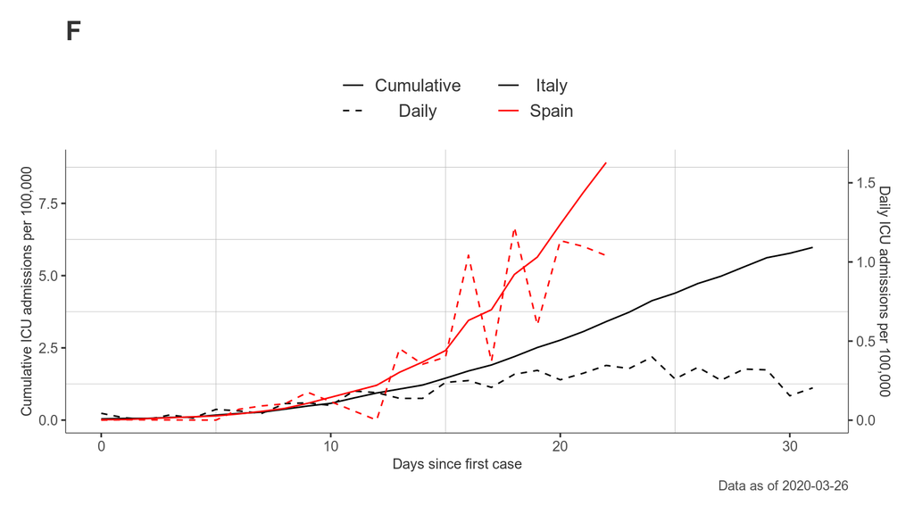

```r
cols <- c('black', 'red')
pd <- df %>% filter(country %in% c('Spain','Italy'))
max_date <- pd %>% group_by(country) %>% summarise(d = max(date)) %>% summarise(d = min(d)) %>% .$d
pd <- pd %>% left_join(world_pop)
pd$value <- pd$uci / pd$pop * 100000
pd$value_non_cum <- pd$uci_non_cum / pd$pop * 100000
pd <- pd %>% filter(value > 0,
                    date <= max_date)
pd <- pd %>%
  make_day_zero_var(start_value = 1, start_var = 'cases') %>%
  group_by(country, date) %>%
  summarise(value = sum(value, na.rm = TRUE),
            value_non_cum = sum(value_non_cum, na.rm = TRUE))

# Define transofrmer value
transformer <- ((max(pd$value) /  max(pd$value_non_cum)) )/ 40
# gather
pd <- pd %>%
  mutate(value_non_cum = value_non_cum / transformer) %>%
  gather(key, value, value:value_non_cum) %>%
  mutate(key = ifelse(key != 'value', 'Daily', 'Cumulative')) %>%
  filter(date >= -5)

ffii <- ggplot(data = pd,
       aes(x = date,
           y = value,
           color = country,
           lty = key)) +
  theme_simple() +
  geom_line() +
  labs(x = 'Days since first case',
       y = 'Cumulative ICU admissions per 100,000',
       title = 'F',
       caption = paste0('Data as of ', max_date)) +
  theme(axis.title = element_text(size = text_size),
        axis.text = element_text(size = text_size* 0.8)) +
  geom_text(data = pd %>% filter(date == max(date),
                                 key == 'Cumulative ICU admissions per 100,000'),
            aes(x = date,
                y = value * 1.05,
                label = scales::comma(round(value, digits = 1))),
            alpha = 0.7,
            show.legend = FALSE) +
  scale_color_manual(name = '', values = cols) +
  scale_y_continuous(sec.axis = sec_axis(trans = ~ . * transformer,
                                         name = 'Daily ICU admissions per 100,000')) +
  scale_linetype_manual(name = '', values = c(1,2)) +
  theme(legend.position = 'top',
        legend.title = element_blank(),
        axis.title = element_text(size = text_size * 0.8),
        legend.text = element_text(size = text_size * 0.98,
                                   hjust = 0.5)) +
  guides(lty = guide_legend(ncol = 1,
                            title.position = 'top'),
         color = guide_legend(ncol = 1,
                              title.position = 'top'))
ffii
```

```r
pdf('6panelforpublication.pdf',
    height =12,
    width = 12)
small_text_size = 7
Rmisc::multiplot(aa, bb, cc,
                 dd, ee, ff,
                 layout = matrix(1:6, nrow = 3, byrow = F))
dev.off()
```

```r
pdf('6panelforpublication_relativetime.pdf',
    height =12,
    width = 12)
small_text_size = 7
Rmisc::multiplot(aaii, bbii, ccii,
                 ddii, eeii, ffii,
                 layout = matrix(1:6, nrow = 3, byrow = F))
dev.off()
```

# OLD CHARTS

### Cumulative cases (absolute)

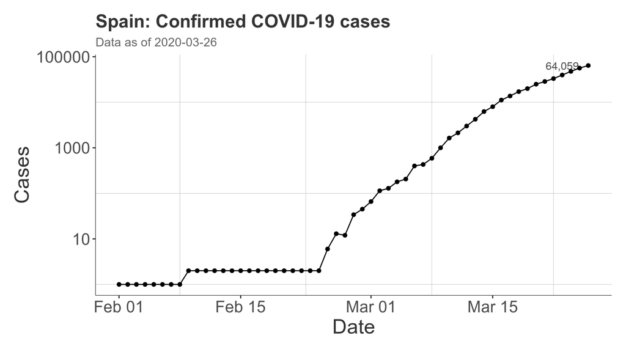

```r
text_size <- 20
pd <- df %>% filter(country == 'Spain')
pd <- pd %>% left_join(world_pop)
pd$value <- pd$cases
pd <- pd %>% filter(value > 0)
pd <- pd %>% group_by(country, date) %>%
  summarise(value = sum(value, na.rm = TRUE))

g1 <- ggplot(data = pd,
       aes(x = date,
           y = value)) +
  theme_simple() +
  geom_line() +
  geom_point() +
  labs(x = 'Date',
       y = 'Cases',
       title = 'Spain: Confirmed COVID-19 cases',
       subtitle = paste0('Data as of ', max(pd$date))) +
  theme(axis.title = element_text(size = text_size),
        axis.text = element_text(size = text_size* 0.8)) +
  geom_text(data = pd %>% filter(date == max(date)),
            aes(x = date - 3,
                y = value,
                label = scales::comma(round(value, digits = 1))),
            alpha = 0.7)
if(ylog){
  g1 <- g1 +
    scale_y_log10()
}
g1
```

Comparison with Italy

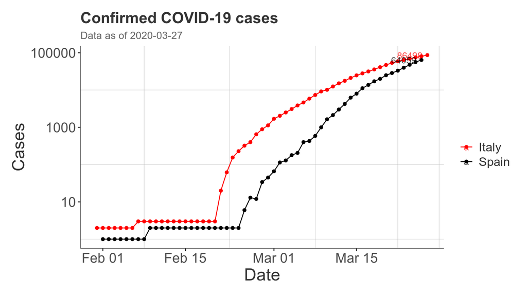

```r
text_size <- 20
pd <- df %>% filter(country %in% c('Italy', 'Spain'))
pd <- pd %>% left_join(world_pop)
pd$value <- pd$cases
pd <- pd %>% filter(value > 0)
pd <- pd %>% group_by(country, date) %>%
  summarise(value = sum(value, na.rm = TRUE))
g1x <- ggplot(data = pd,
       aes(x = date,
           y = value)) +
  theme_simple() +
  geom_line(aes(color = country)) +
  geom_point(aes(color = country)) +
  labs(x = 'Date',
       y = 'Cases',
       title = 'Confirmed COVID-19 cases',
       subtitle = paste0('Data as of ', max(pd$date))) +
  theme(axis.title = element_text(size = text_size),
        axis.text = element_text(size = text_size* 0.8)) +
  geom_text(data = pd %>% filter(date == max(date)),
            aes(x = date - 3,
                y = value,
                color = country,
                label = round(value, digits = 1)),
            alpha = 0.7) +
  scale_color_manual(name = '', values = c('red', 'black'))
if(ylog){
  g1x <- g1x + scale_y_log10()
}
g1x
```

### Cumulative deaths (absolute)

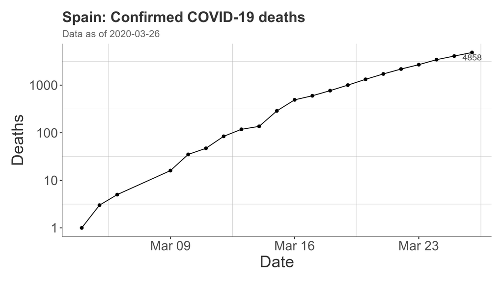

```r
text_size <- 20

pd <- df %>% filter(country == 'Spain')
pd <- pd %>% left_join(world_pop)
pd$value <- pd$deaths
pd <- pd %>% filter(value > 0)
pd <- pd %>% group_by(country, date) %>%
  summarise(value = sum(value, na.rm = TRUE))

g2 <- ggplot(data = pd,
       aes(x = date,
           y = value)) +
  theme_simple() +
  geom_line() +
  geom_point() +
  labs(x = 'Date',
       y = 'Deaths',
       title = 'Spain: Confirmed COVID-19 deaths',
       subtitle = paste0('Data as of ', max(pd$date))) +
  theme(axis.title = element_text(size = text_size),
        axis.text = element_text(size = text_size* 0.8)) +
  geom_text(data = pd %>% filter(date == max(date)),
            aes(x = date,
                y = value - ifelse(ylog, 1000, 300),
                label = round(value, digits = 1)),
            alpha = 0.7)
if(ylog){
  g2 <- g2 + scale_y_log10()
}
g2
```

Comparison with Italy

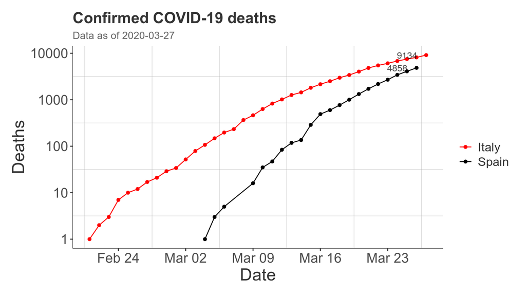

```r
text_size <- 20
pd <- df %>% filter(country %in% c('Italy', 'Spain'))
pd <- pd %>% left_join(world_pop)
pd$value <- pd$deaths
pd <- pd %>% filter(value > 0)
pd <- pd %>% group_by(country, date) %>%
  summarise(value = sum(value, na.rm = TRUE))


g2x <- ggplot(data = pd,
       aes(x = date,
           y = value)) +
  theme_simple() +
  geom_line(aes(color = country)) +
  geom_point(aes(color = country)) +
  labs(x = 'Date',
       y = 'Deaths',
       title = 'Confirmed COVID-19 deaths',
       subtitle = paste0('Data as of ', max(pd$date))) +
  theme(axis.title = element_text(size = text_size),
        axis.text = element_text(size = text_size* 0.8)) +
  geom_text(data = pd %>% filter(date == max(date)),
            aes(x = date - 2,
                y = value,
                label = round(value, digits = 1)),
            alpha = 0.7) +
  scale_color_manual(name = '', values = c('red', 'black'))
if(ylog){
  g2x <- g2x + scale_y_log10()
}
g2x
```

### Cumulative cases by population

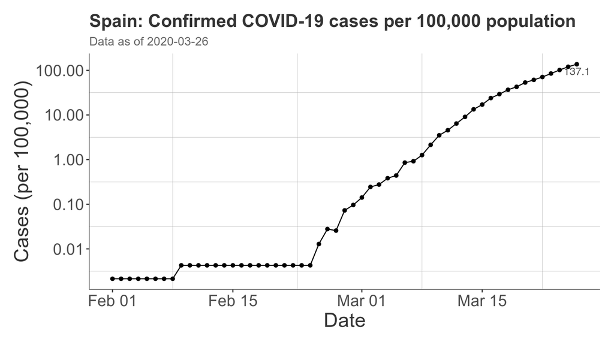

```r
text_size <- 20

pd <- df %>% filter(country == 'Spain')
pd <- pd %>% left_join(world_pop)
pd$value <- pd$cases / pd$pop * 100000
pd <- pd %>% filter(value > 0)
pd <- pd %>% group_by(country, date) %>%
  summarise(value = sum(value, na.rm = TRUE))

g3 <- ggplot(data = pd,
       aes(x = date,
           y = value)) +
  theme_simple() +
  geom_line() +
  geom_point() +
  labs(x = 'Date',
       y = 'Cases (per 100,000)',
       title = 'Spain: Confirmed COVID-19 cases per 100,000 population',
       subtitle = paste0('Data as of ', max(pd$date))) +
  theme(axis.title = element_text(size = text_size),
        axis.text = element_text(size = text_size* 0.8)) +
  geom_text(data = pd %>% filter(date == max(date)),
            aes(x = date,
                y = value - ifelse(ylog, 40, 10),
                label = round(value, digits = 1)),
            alpha = 0.7)
if(ylog){
  g3 <- g3 + scale_y_log10()
}
g3
```

Comparison with Italy

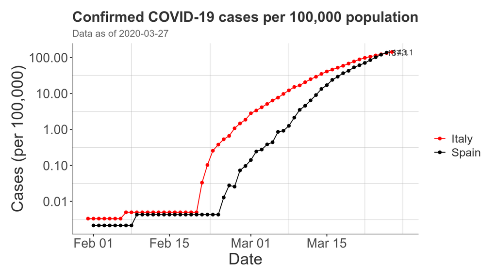

```r
text_size <- 20

pd <- df %>% filter(country %in% c('Spain', 'Italy'))
pd <- pd %>% left_join(world_pop)
pd$value <- pd$cases / pd$pop * 100000
pd <- pd %>% filter(value > 0)
pd <- pd %>% group_by(country, date) %>%
  summarise(value = sum(value, na.rm = TRUE))

g3x <- ggplot(data = pd,
       aes(x = date,
           y = value)) +
  theme_simple() +
  geom_line(aes(color = country)) +
  geom_point(aes(color = country)) +
  labs(x = 'Date',
       y = 'Cases (per 100,000)',
       title = 'Confirmed COVID-19 cases per 100,000 population',
       subtitle = paste0('Data as of ', max(pd$date))) +
  theme(axis.title = element_text(size = text_size),
        axis.text = element_text(size = text_size* 0.8)) +
  geom_text(data = pd %>% filter(date == max(date)),
            aes(x = date +2,
                y = value,
                label = round(value, digits = 1)),
            alpha = 0.7) +
  scale_color_manual(name ='',
                     values = c('red', 'black'))

if(ylog){
  g3x <- g3x + scale_y_log10()
}
g3x
```

### Cumulative deaths by population

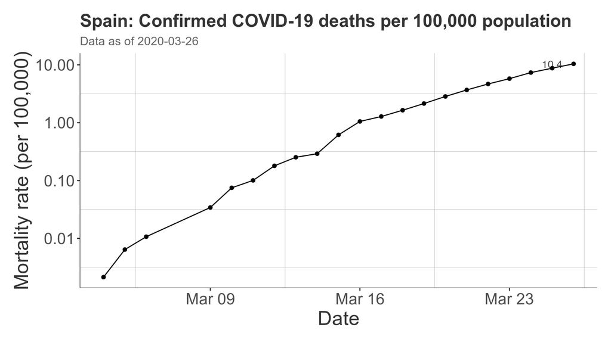

```r
text_size <- 20

pd <- df %>% filter(country == 'Spain')
pd <- pd %>% left_join(world_pop)
pd$value <- pd$deaths / pd$pop * 100000
pd <- pd %>% filter(value > 0)
pd <- pd %>% group_by(country, date) %>%
  summarise(value = sum(value, na.rm = TRUE))

g4 <- ggplot(data = pd,
       aes(x = date,
           y = value)) +
  theme_simple() +
  geom_line() +
  geom_point() +
  labs(x = 'Date',
       y = 'Mortality rate (per 100,000)',
       title = 'Spain: Confirmed COVID-19 deaths per 100,000 population',
       subtitle = paste0('Data as of ', max(pd$date))) +
  theme(axis.title = element_text(size = text_size),
        axis.text = element_text(size = text_size* 0.8)) +
  geom_text(data = pd %>% filter(date == max(date)),
            aes(x = date -1,
                y = value,
                label = round(value, digits = 1)),
            alpha = 0.7)

if(ylog){
  g4 <- g4 + scale_y_log10()
}
g4
```

Comparison with Italy

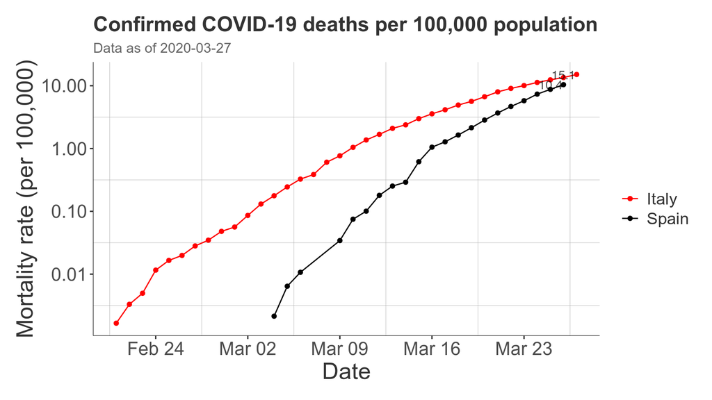

```r
text_size <- 20

pd <- df %>% filter(country %in% c('Spain', 'Italy'))
pd <- pd %>% left_join(world_pop)
pd$value <- pd$deaths / pd$pop * 100000
pd <- pd %>% filter(value > 0)
pd <- pd %>% group_by(country, date) %>%
  summarise(value = sum(value, na.rm = TRUE))

g4x <- ggplot(data = pd,
       aes(x = date,
           y = value)) +
  theme_simple() +
  geom_line(aes(color = country)) +
  geom_point(aes(color = country)) +
  labs(x = 'Date',
       y = 'Mortality rate (per 100,000)',
       title = 'Confirmed COVID-19 deaths per 100,000 population',
       subtitle = paste0('Data as of ', max(pd$date))) +
  theme(axis.title = element_text(size = text_size),
        axis.text = element_text(size = text_size* 0.8)) +
  geom_text(data = pd %>% filter(date == max(date)),
            aes(x = date -1,
                y = value,
                label = round(value, digits = 1)),
            alpha = 0.7) +
  scale_color_manual(name ='', values = c('red', 'black') )
if(ylog){
  g4x <- g4x + scale_y_log10()
}
g4x
```

# UCI charts

Spain only, UCI, (not pop adjusted)

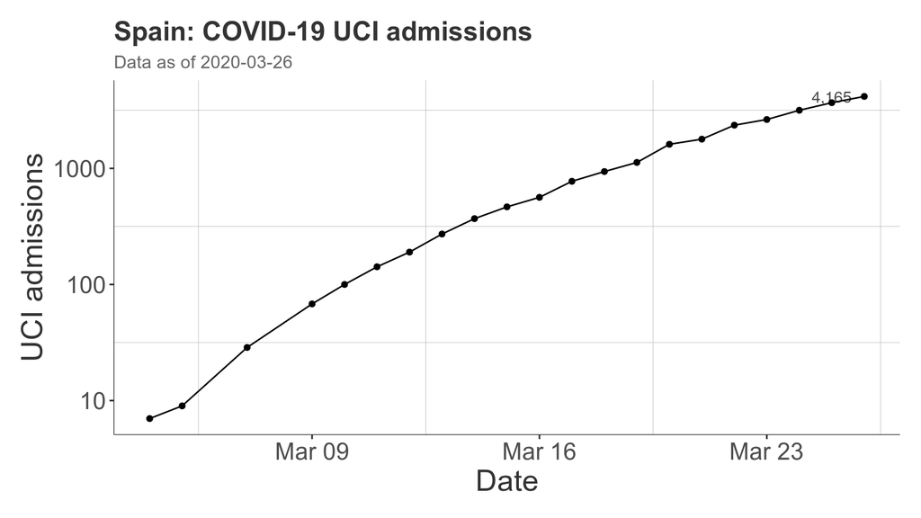

```r
text_size <- 20
pd <- esp_df %>% mutate(iso = 'ESP') %>% #bind_rows(ita %>% mutate(iso = 'ITA')) %>%
  group_by(iso, date) %>%
  summarise(uci = sum(uci),
            deaths = sum(deaths),
            cases = sum(cases))
pd <- pd %>% left_join(world_pop)
pd$value <- pd$uci # /pd$pop * 100000
pd <- pd %>% filter(value > 0)
pd <- pd %>% group_by(country, date) %>%
  summarise(value = sum(value, na.rm = TRUE))

g5 <- ggplot(data = pd,
       aes(x = date,
           y = value)) +
  theme_simple() +
  geom_line() +
  geom_point() +
  labs(x = 'Date',
       y = 'UCI admissions',
       title = 'Spain: COVID-19 UCI admissions',
       subtitle = paste0('Data as of ', max(pd$date))) +
  theme(axis.title = element_text(size = text_size),
        axis.text = element_text(size = text_size* 0.8)) +
  geom_text(data = pd %>% filter(date == max(date)),
            aes(x = date - 1,
                y = value,
                label = scales::comma(round(value, digits = 1))),
            alpha = 0.7)
if(ylog){
  g5 <- g5 +
    scale_y_log10()
}
g5
```

UCI total admissions (not pop adjusted)

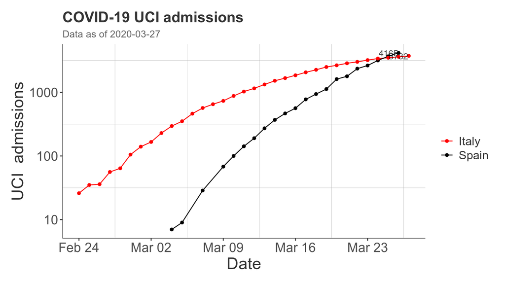

```r
text_size <- 20

pd <- esp_df %>% mutate(iso = 'ESP') %>% bind_rows(ita %>% mutate(iso = 'ITA')) %>%
  group_by(iso, date) %>%
  summarise(uci = sum(uci),
            deaths = sum(deaths),
            cases = sum(cases))
pd <- pd %>% left_join(world_pop)
pd$value <- pd$uci # /pd$pop * 100000
pd <- pd %>% filter(value > 0, !is.na(value))


g5x <- ggplot(data = pd,
       aes(x = date,
           y = value)) +
  theme_simple() +
  geom_line(aes(color = country)) +
  geom_point(aes(color = country)) +
  labs(x = 'Date',
       y = 'UCI  admissions',
       title = 'COVID-19 UCI admissions',
       subtitle = paste0('Data as of ', max(pd$date))) +
  theme(axis.title = element_text(size = text_size),
        axis.text = element_text(size = text_size* 0.8)) +
  geom_text(data = pd %>% filter(date == max(date)),
            aes(x = date -1,
                y = value,
                label = round(value, digits = 1)),
            alpha = 0.7) +
  scale_color_manual(name ='', values = c('red', 'black') )
if(ylog){
  g5x <- g5x + scale_y_log10()
}
g5x
```

Spain only, UCI, (pop adjusted)

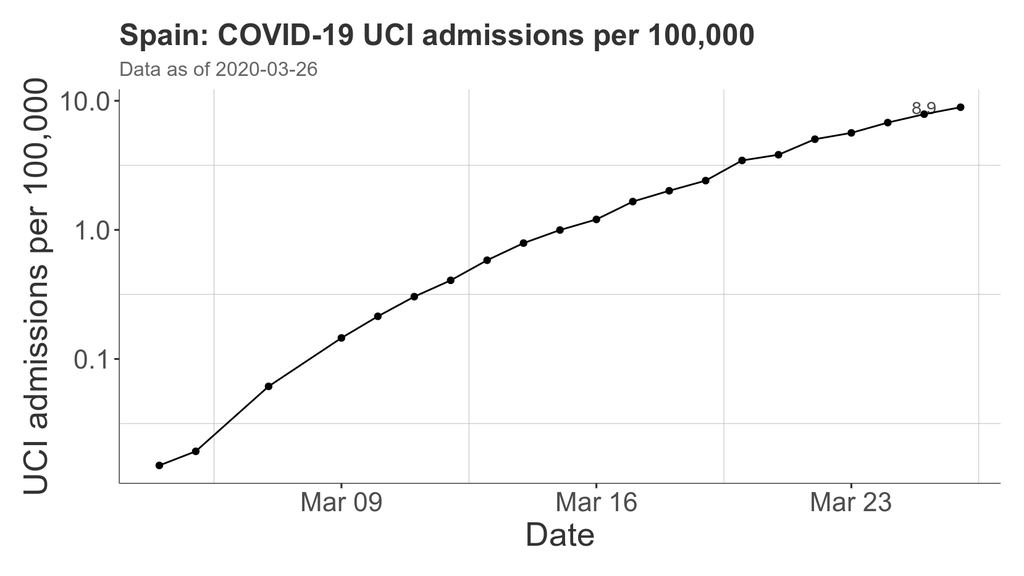

```r
text_size <- 20
pd <- esp_df %>% mutate(iso = 'ESP') %>% #bind_rows(ita %>% mutate(iso = 'ITA')) %>%
  group_by(iso, date) %>%
  summarise(uci = sum(uci),
            deaths = sum(deaths),
            cases = sum(cases))
pd <- pd %>% left_join(world_pop)
pd$value <- pd$uci /pd$pop * 100000
pd <- pd %>% filter(value > 0)
pd <- pd %>% group_by(country, date) %>%
  summarise(value = sum(value, na.rm = TRUE))

g6 <- ggplot(data = pd,
       aes(x = date,
           y = value)) +
  theme_simple() +
  geom_line() +
  geom_point() +
  labs(x = 'Date',
       y = 'UCI admissions per 100,000',
       title = 'Spain: COVID-19 UCI admissions per 100,000',
       subtitle = paste0('Data as of ', max(pd$date))) +
  theme(axis.title = element_text(size = text_size),
        axis.text = element_text(size = text_size* 0.8)) +
  geom_text(data = pd %>% filter(date == max(date)),
            aes(x = date - 1,
                y = value,
                label = round(value, digits = 1)),
            alpha = 0.7)
if(ylog){
  g6 <- g6 +
    scale_y_log10()
}
g6
```

UCI admissions (pop adjusted)

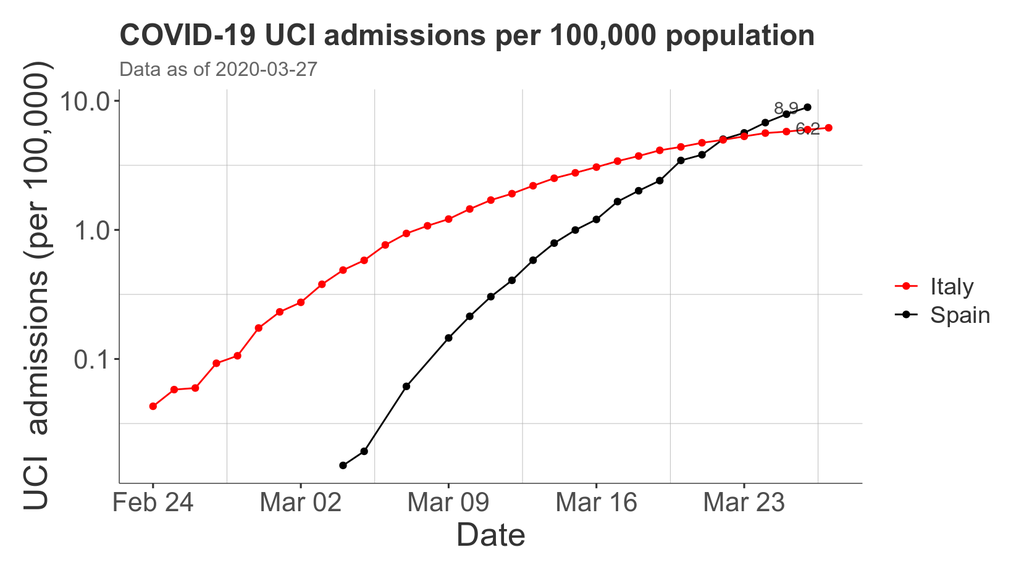

```r
text_size <- 20

pd <- esp_df %>% mutate(iso = 'ESP') %>% bind_rows(ita %>% mutate(iso = 'ITA')) %>%
  group_by(iso, date) %>%
  summarise(uci = sum(uci),
            deaths = sum(deaths),
            cases = sum(cases))
pd <- pd %>% left_join(world_pop)
pd$value <- pd$uci / pd$pop * 100000
pd <- pd %>% filter(value > 0, !is.na(value))


g6x <- ggplot(data = pd,
       aes(x = date,
           y = value)) +
  theme_simple() +
  geom_line(aes(color = country)) +
  geom_point(aes(color = country)) +
  labs(x = 'Date',
       y = 'UCI  admissions (per 100,000)',
       title = 'COVID-19 UCI admissions per 100,000 population',
       subtitle = paste0('Data as of ', max(pd$date))) +
  theme(axis.title = element_text(size = text_size),
        axis.text = element_text(size = text_size* 0.8)) +
  geom_text(data = pd %>% filter(date == max(date)),
            aes(x = date -1,
                y = value,
                label = round(value, digits = 1)),
            alpha = 0.7) +
  scale_color_manual(name ='', values = c('red', 'black') )
if(ylog){
  g6x <- g6x + scale_y_log10()
}
g6x
```

# New charts

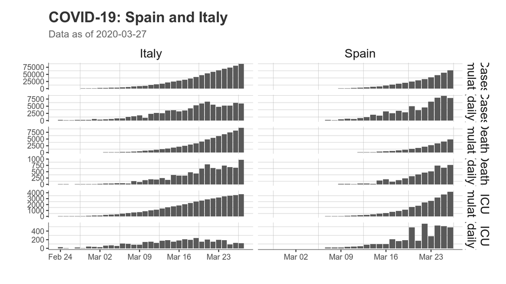

```r
text_size <- 12
pd <- esp_df %>% mutate(iso = 'ESP',
                        cases_non_cum = cases_non_cum) %>% bind_rows(ita %>% mutate(iso = 'ITA') %>% mutate(cases = cases))

pd <- pd %>% group_by(iso, date) %>%
  summarise(uci = sum(uci, na.rm = TRUE),
            deaths = sum(deaths, na.rm = TRUE),
            cases = sum(cases, na.rm = TRUE),
            uci_non_cum = sum(uci_non_cum, na.rm = TRUE),
            deaths_non_cum = sum(deaths_non_cum, na.rm = TRUE),
            cases_non_cum = sum(cases_non_cum, na.rm = TRUE)) %>%
  ungroup %>%
  tidyr::gather(key, value, uci:cases_non_cum)
pd <- pd %>% left_join(world_pop %>% dplyr::select(iso, pop, country))
pd$p <- pd$value / pd$pop * 100000

keys <- tibble(key = c('cases', 'cases_non_cum',
                       'deaths', 'deaths_non_cum',
                       'uci', 'uci_non_cum'),
               new_key = c('Cases\n(cumulative)',
                 'Cases\n(daily)',
                 'Deaths\n(cumulative)',
                 'Deaths\n(daily)',
                 'ICU\n(cumulative)',
                 'ICU\n(daily)'))
pd <- left_join(pd, keys) %>%
  dplyr::select(-key) %>%
  dplyr::rename(key = new_key)
ggplot(data = pd,
       aes(x = date,
           y = value)) +
  theme_simple() +
  facet_grid(key~country, scales = 'free') +
  geom_bar(stat = 'identity') +

  labs(x = '',
       y = '',
       title = 'COVID-19: Spain and Italy',
       subtitle = paste0('Data as of ', max(pd$date))) +
  theme(axis.title = element_text(size = text_size),
        axis.text = element_text(size = text_size* 0.8),
        strip.text.y = element_text(hjust = 0.5, size = 15),
        strip.text.x = element_text(size = 15, hjust = 0.5))
```

```r
ggsave('~/Desktop/special.pdf')
```

```r
pdf('~/Desktop/alberto1_LOG.pdf',
    height =12,
    width = 12)
small_text_size = 9
Rmisc::multiplot(g1 + theme(axis.title = element_text(size = small_text_size),
        axis.text = element_text(size = small_text_size), plot.title = element_text(size = small_text_size * 1.4)),
        g2  + theme(axis.title = element_text(size = small_text_size),
        axis.text = element_text(size = small_text_size), plot.title = element_text(size = small_text_size * 1.4)),
                g5  + theme(axis.title = element_text(size = small_text_size),
        axis.text = element_text(size = small_text_size), plot.title = element_text(size = small_text_size * 1.4)),
        g3  + theme(axis.title = element_text(size = small_text_size),
        axis.text = element_text(size = small_text_size), plot.title = element_text(size = small_text_size * 1.4)),
                g4  + theme(axis.title = element_text(size = small_text_size),
        axis.text = element_text(size = small_text_size), plot.title = element_text(size = small_text_size * 1.4)),
        g6  + theme(axis.title = element_text(size = small_text_size),
        axis.text = element_text(size = small_text_size), plot.title = element_text(size = small_text_size * 1.4)),
                 cols = 2)
dev.off()
```

```r
pdf('~/Desktop/alberto1_with_italy_LOG.pdf',
    height =12,
    width = 12)
small_text_size = 9
Rmisc::multiplot(g1x + theme(axis.title = element_text(size = small_text_size),
        axis.text = element_text(size = small_text_size), plot.title = element_text(size = small_text_size * 1.4)),
        g2x  + theme(axis.title = element_text(size = small_text_size),
        axis.text = element_text(size = small_text_size), plot.title = element_text(size = small_text_size * 1.4)),
                g5x  + theme(axis.title = element_text(size = small_text_size),
        axis.text = element_text(size = small_text_size), plot.title = element_text(size = small_text_size * 1.4)),
        g3x  + theme(axis.title = element_text(size = small_text_size),
        axis.text = element_text(size = small_text_size), plot.title = element_text(size = small_text_size * 1.4)),
        g4x  + theme(axis.title = element_text(size = small_text_size),
        axis.text = element_text(size = small_text_size), plot.title = element_text(size = small_text_size * 1.4)),

        g6x  + theme(axis.title = element_text(size = small_text_size),
        axis.text = element_text(size = small_text_size), plot.title = element_text(size = small_text_size * 1.4)),
                 cols = 2)
dev.off()
```